# Quiz 1 Assignment 4

Wilmer Uruchi

10/19/2018

## Building the DataSet

First, visualize the current dataset:

```r
load("Boston2015.RData")
```

Using dplyr for some data transformation:

```r
library(dplyr)
library(lubridate)
library(stringr)
```

```r
library("FactoMineR")
```

I am going to build the dataset using the imported dataset marathon_results_2015

```r
Boston2015SubSet <- marathon_results_2015 %>%
  filter(Age >= 20, Age <= 50, M.F == "F")
```

Analyze Data Types:

```r
str(Boston2015SubSet)
```

```
## 'data.frame':    10124 obs. of  25 variables:
##  $ X            : int  30 31 33 39 43 51 53 61 74 77 ...
##  $ Bib          : Factor w/ 26598 levels "1","10","10000",..: 26560 26572 26550 26551 26597 26598 26581 26591 26570 26595 ...
##  $ Name         : Factor w/ 26540 levels "Aaron, Gary G",..: 20514 5837 5502 13974 3856 12328 12041 7422 3849 6351 ...
##  $ Age          : int  30 25 27 31 31 34 28 33 26 27 ...
##  $ M.F          : Factor w/ 2 levels "F","M": 1 1 1 1 1 1 1 1 1 1 ...
##  $ City         : Factor w/ 5616 levels "075100 Otopeni - Ilfov",..: 3518 4533 184 4137 2870 504 4533 3920 2250 3084 ...
##  $ State        : Factor w/ 70 levels "","AA","AB","AE",..: 1 1 1 31 1 1 1 51 1 1 ...
##  $ Country      : Factor w/ 79 levels "AHO","AND","ARG",..: 42 26 26 76 42 42 26 76 42 9 ...
##  $ Citizen      : Factor w/ 83 levels "","ARG","AUS",..: 1 1 1 1 1 1 1 1 1 1 ...
##  $ X.1          : Factor w/ 3 levels "","MI","VI": 1 1 1 1 1 1 1 1 1 1 ...
##  $ X5K          : Factor w/ 1328 levels "-","0:14:43",..: 43 42 41 44 43 42 42 42 42 51 ...
##  $ X10K         : Factor w/ 2435 levels "-","0:29:43",..: 50 49 49 50 50 49 49 50 49 49 ...
##  $ X15K         : Factor w/ 3480 levels "-","0:44:57",..: 57 56 57 56 57 56 57 57 56 57 ...
##  $ X20K         : Factor w/ 4541 levels "-","1:00:28",..: 47 47 48 47 48 47 47 48 47 48 ...
##  $ Half         : Factor w/ 4746 levels "-","1:04:01",..: 48 48 48 48 49 47 48 48 48 49 ...
##  $ X25K         : Factor w/ 5573 levels "-","1:16:05",..: 42 42 43 42 43 42 42 43 42 43 ...
##  $ X30K         : Factor w/ 6545 levels "-","1:31:59",..: 43 42 43 42 43 42 43 44 42 50 ...
##  $ X35K         : Factor w/ 7530 levels "-","1:47:59",..: 39 39 39 38 39 39 39 45 39 58 ...
##  $ X40K         : Factor w/ 8380 levels "-","2:02:39",..: 36 36 36 39 42 43 43 59 51 71 ...
##  $ Pace         : Factor w/ 555 levels "0:04:56","0:04:58",..: 22 22 23 24 25 26 27 29 32 32 ...
##  $ Proj.Time    : Factor w/ 1 level "-": 1 1 1 1 1 1 1 1 1 1 ...
##  $ Official.Time: Factor w/ 8718 levels "2:09:17","2:09:48",..: 30 31 33 38 41 49 51 59 72 75 ...
##  $ Overall      : int  31 32 34 40 44 52 54 62 75 78 ...
##  $ Gender       : int  1 2 3 4 5 6 7 9 10 11 ...
##  $ Division     : int  1 2 3 4 5 6 7 9 10 11 ...
```

Now, I am going to transform some fields so I can use them in the PCA.

```r
Boston2015SubSet <- Boston2015SubSet %>%
  mutate(X10ktotal = as.numeric(X10K), PaceTotal = as.numeric(Pace),
         X5kseconds = as.numeric(difftime(as.POSIXct(X5K, format = '%H:%M:%S'), as.POSIXct('00:00:00', format = '%H:%M:%S'), units = 'secs')),
         X10kseconds = as.numeric(difftime(as.POSIXct(X10K, format = '%H:%M:%S'), as.POSIXct('00:00:00', format = '%H:%M:%S'), units = 'secs')),
         PaceSeconds = as.numeric(difftime(as.POSIXct(Pace, format = '%H:%M:%S'), as.POSIXct('00:00:00', format = '%H:%M:%S'), units = 'secs')),
         OfficialTimeSeconds = as.numeric(difftime(as.POSIXct(Official.Time, format = '%H:%M:%S'), as.POSIXct('00:00:00', format = '%H:%M:%S'), units = 'secs')),
         BibNumber = str_extract(Bib, "[F]"))
```

So, perhaps it is not good to include all those professionals into the model since they are expected to have results that are about 3 standard deviations from the median.

```r
Boston2015FemaleNoPro <- Boston2015SubSet %>%
  filter(is.na(BibNumber) == TRUE, is.na(OfficialTimeSeconds) == FALSE, is.na(X5kseconds) == FALSE,
         is.na(X10kseconds) == FALSE)
```

A final transformation:

```r
Boston2015FemaleNoPro <- Boston2015FemaleNoPro %>%
  mutate(BibN = as.numeric(as.character(Bib)))
```

## Doing PCA

Now lets look at the PCA of the data collected:

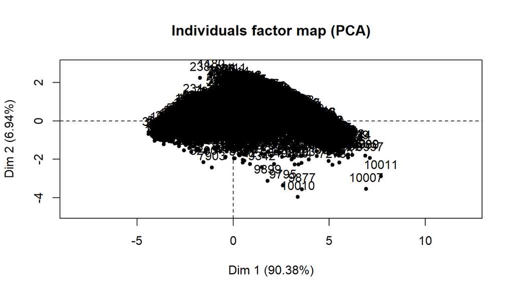

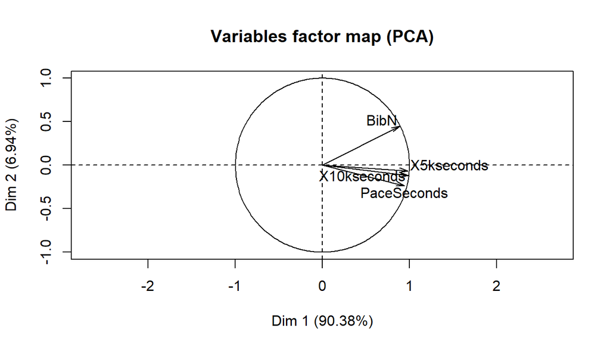

[output not shown]

This graphic shows that the stronger correlation is between X5kseconds, X10kseconds, and PaceSeconds, so lets make another PCA between these variables:

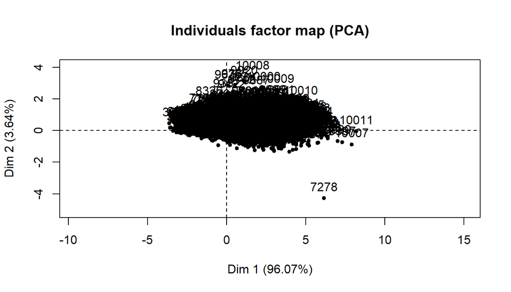

```r
Boston2015FemaleNoPro.PCA<-Boston2015FemaleNoPro[, c("X5kseconds",
  "X10kseconds", "PaceSeconds")]
res<-PCA(Boston2015FemaleNoPro.PCA , scale.unit=TRUE, ncp=5, graph = FALSE)
plot.PCA(res, axes=c(1, 2), choix="ind", habillage="none", col.ind="black",
  col.ind.sup="blue", col.quali="magenta", label=c("ind", "ind.sup", "quali"),
  new.plot=TRUE)
```

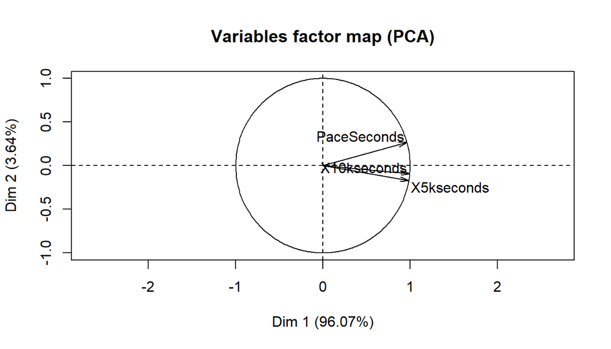

```r
plot.PCA(res, axes=c(1, 2), choix="var", new.plot=TRUE, col.var="black",
  col.quanti.sup="blue", label=c("var", "quanti.sup"), lim.cos2.var=0)
```

```r
summary(res, nb.dec = 3, nbelements=10, nbind = 10, ncp = 3, file="")
```

```
##
## Call:
## PCA(X = Boston2015FemaleNoPro.PCA, scale.unit = TRUE, ncp = 5,
##      graph = FALSE)
##
##
## Eigenvalues
##                        Dim.1   Dim.2   Dim.3
## Variance               2.882   0.109   0.009
## % of var.             96.068   3.645   0.287
## Cumulative % of var.  96.068  99.713 100.000
##
## Individuals (the 10 first)
##                 Dist    Dim.1    ctr   cos2    Dim.2    ctr   cos2
## 1           |  3.397 | -3.397  0.040  1.000 | -0.015  0.000  0.000 |
## 2           |  3.187 | -3.185  0.035  0.999 | -0.118  0.001  0.001 |
## 3           |  3.589 | -3.585  0.045  0.997 |  0.179  0.003  0.002 |
## 4           |  3.164 | -3.162  0.035  0.999 | -0.106  0.001  0.001 |
## 5           |  3.549 | -3.544  0.044  0.997 |  0.191  0.003  0.003 |
## 6           |  3.346 | -3.346  0.039  1.000 |  0.053  0.000  0.000 |
## 7           |  3.312 | -3.312  0.038  1.000 |  0.041  0.000  0.000 |
## 8           |  3.197 | -3.197  0.035  1.000 |  0.006  0.000  0.000 |
## 9           |  3.249 | -3.249  0.037  1.000 |  0.045  0.000  0.000 |
## 10          |  3.366 | -3.364  0.039  0.999 |  0.124  0.001  0.001 |
##              Dim.3    ctr   cos2
## 1           -0.023  0.001  0.000 |
## 2           -0.027  0.001  0.000 |
## 3           -0.041  0.002  0.000 |
## 4           -0.017  0.000  0.000 |
## 5           -0.017  0.000  0.000 |
## 6           -0.022  0.001  0.000 |
## 7           -0.004  0.000  0.000 |
## 8           -0.005  0.000  0.000 |
## 9           -0.021  0.001  0.000 |
## 10          -0.015  0.000  0.000 |
##
## Variables
##                Dim.1    ctr   cos2    Dim.2    ctr   cos2    Dim.3    ctr
## X5kseconds  |  0.984 33.581  0.968 | -0.169 26.257  0.029 |  0.059 40.161
## X10kseconds |  0.993 34.227  0.986 | -0.093  7.829  0.009 | -0.071 57.944
## PaceSeconds |  0.963 32.191  0.928 |  0.268 65.914  0.072 |  0.013  1.895
##               cos2
## X5kseconds   0.003 |
## X10kseconds  0.005 |
## PaceSeconds  0.000 |
```

So, it seems that the variables X10kseconds, and X5kseconds are strongly correlated, lets measure the correlation between them, and also with the response Variable OfficalTimeSeconds (Official Time in seconds). Also, lets measure the correlation between PaceSeconds and OfficialTimeSeconds.

```r
Boston2015FemaleNoPro %>%
  summarise(cor5k_to_10k = cor(X10kseconds, X5kseconds),
            cor5k_to_Final = cor(OfficialTimeSeconds, X5kseconds),
            cor10k_to_Final = cor(OfficialTimeSeconds, X10kseconds),
            Pace_to_Final = cor(OfficialTimeSeconds, PaceSeconds))
```

```
##   cor5k_to_10k cor5k_to_Final cor10k_to_Final Pace_to_Final
## 1    0.9886097      0.9028969       0.9309484     0.9999938
```

It looks like these are the variable that should be included in the construction of the model:

```r
RegModel.2 <- lm(OfficialTimeSeconds~PaceSeconds+X5kseconds+X10kseconds,
  data=Boston2015FemaleNoPro)
summary(RegModel.2)
```

```
##
## Call:
## lm(formula = OfficialTimeSeconds ~ PaceSeconds + X5kseconds +
##     X10kseconds, data = Boston2015FemaleNoPro)
##
## Residuals:
##     Min      1Q  Median      3Q     Max
## -67.011  -6.639   0.010   6.660  17.280
##
## Coefficients:
##               Estimate Std. Error  t value Pr(>|t|)
## (Intercept) -13.655576   0.585842  -23.309   <2e-16 ***
## PaceSeconds  26.212663   0.002655 9871.745   <2e-16 ***
## X5kseconds    0.004441   0.002499    1.777   0.0755 .
## X10kseconds  -0.000953   0.001484   -0.642   0.5206
## ---
## Signif. codes:  0 '***' 0.001 '**' 0.01 '*' 0.05 '.' 0.1 ' ' 1
##
## Residual standard error: 7.637 on 10007 degrees of freedom
## Multiple R-squared:      1,  Adjusted R-squared:      1
## F-statistic: 2.71e+08 on 3 and 10007 DF,  p-value: < 2.2e-16
```

Now, lets use the model to predict the Official time for a sample of 10 participants:

```r
new1 <- data.frame(X5kseconds=1178,X10kseconds=2347,PaceSeconds=378)
new2 <- data.frame(X5kseconds=1250,X10kseconds=2413,PaceSeconds=381)
new3 <- data.frame(X5kseconds=1131,X10kseconds=2238,PaceSeconds=382)
new4 <- data.frame(X5kseconds=1218,X10kseconds=2414,PaceSeconds=383)
new5 <- data.frame(X5kseconds=1138,X10kseconds=2284,PaceSeconds=385)
new6 <- data.frame(X5kseconds=1177,X10kseconds=2351,PaceSeconds=385)
new7 <- data.frame(X5kseconds=1185,X10kseconds=2355,PaceSeconds=386)
new8 <- data.frame(X5kseconds=1203,X10kseconds=2388,PaceSeconds=389)
new9 <- data.frame(X5kseconds=1190,X10kseconds=2376,PaceSeconds=389)
new10 <- data.frame(X5kseconds=1168,X10kseconds=2336,PaceSeconds=389)
pred1 = predict(RegModel.2, newdata = new1, interval="prediction")[1]
pred2 = predict(RegModel.2, newdata = new2, interval="prediction")[1]
pred3 = predict(RegModel.2, newdata = new3, interval="prediction")[1]
pred4 = predict(RegModel.2, newdata = new4, interval="prediction")[1]
pred5 = predict(RegModel.2, newdata = new5, interval="prediction")[1]
pred6 = predict(RegModel.2, newdata = new6, interval="prediction")[1]
pred7 = predict(RegModel.2, newdata = new7, interval="prediction")[1]
pred8 = predict(RegModel.2, newdata = new8, interval="prediction")[1]
pred9 = predict(RegModel.2, newdata = new9, interval="prediction")[1]
pred10 = predict(RegModel.2, newdata = new10, interval="prediction")[1]

base1 <- c(pred1,pred2,pred3,pred4,pred5,pred6,pred7,pred8,pred9,pred10)

sample1 <- Boston2015FemaleNoPro %>%
  filter(X <= 938) %>%
  select(X5kseconds, X10kseconds, PaceSeconds, OfficialTimeSeconds)

sample1$predictions = base1

sample1
```

```
##    X5kseconds X10kseconds PaceSeconds OfficialTimeSeconds predictions
## 1        1178        2347         378                9896    9897.726
## 2        1215        2413         381                9982    9976.621
## 3        1131        2283         382                9994   10002.472
## 4        1218        2414         383               10035   10028.903
## 5        1138        2284         385               10087   10081.097
## 6        1177        2351         385               10090   10081.206
## 7        1185        2355         386               10112   10107.451
## 8        1203        2388         389               10179   10186.137
## 9        1190        2376         389               10199   10186.091
## 10       1168        2336         389               10199   10186.031
```

```r
DistributionSample = sample1 %>%
                      select(OfficialTimeSeconds,predictions)
DistributionSample
```

```
##    OfficialTimeSeconds predictions
## 1                 9896    9897.726
## 2                 9982    9976.621
## 3                 9994   10002.472
## 4                10035   10028.903
## 5                10087   10081.097
## 6                10090   10081.206
## 7                10112   10107.451
## 8                10179   10186.137
## 9                10199   10186.091
## 10               10199   10186.031
```

Lets apply chi-square test:

```r
Test=chisq.test(DistributionSample, correct=FALSE)
Test
```

```
##
##  Pearson's Chi-squared test
##
## data:  DistributionSample
## X-squared = 0.024903, df = 9, p-value = 1
```

Given p-value > 0.05 we can’t reject the null hypothesis that states that both distributions are nearly equal.

So I think there is strong evidence that the predictions are mostly accurate.